# Shining a Light on U.S. Solar Energy Generation

Jonathan Tan

2/3/2019

# Setup

```r
knitr::opts_chunk$set(echo = TRUE)
# Data analysis libraries
library(tidyverse)
```

```r
library(magrittr) # extended pipe functionality
```

```r
library(lubridate) # dealing with date objects
```

```r
library(here) # for OS-agnostic filepaths
```

```r
library(readxl) # for reading Excel files
# Visualization libraries
library(ggrepel) # for neater text labels
library(gghighlight) # for easier highlighting
library(geofacet) # for making facets looks like the USA
library(ggridges)
```

```r
library(extrafont) # for... extra fonts
```

```r
library(gridExtra) # for combining plots
```

```r
# Geospatial tools and related libraries
library(sf)
```

```r
library(zipcode) # for geocoding zipcodes
library(noncensus) # for more geocoding data
library(rnaturalearth)
library(rnaturalearthdata)
# Load previously-imported data
# Data assemby process captured in /scripts/data-import.R
load(here('data', 'solar_data_master.RData'))
```

```r
# Set custom theme
theme_custom <- function(base_size = 12, base_family = "",
                         base_line_size = base_size/22,
                         base_rect_size = base_size/22) {
  theme_minimal(base_size = base_size, base_family = base_family,
             base_line_size = base_line_size,
             base_rect_size = base_rect_size) %+replace%
    theme(panel.grid.minor = element_blank(),
          panel.grid.major = element_line(color = "#EEEEEE"),
          plot.title = element_text(family = "Asap SemiBold",
                                    size = 16,
                                    hjust = 0,
                                    margin = margin(5, 0, 5, 0),
                                    color = "#0F0F0F"),
          plot.subtitle = element_text(family = "Asap",
                                       size = 12,
                                       hjust = 0,
                                       margin = margin(0, 0, 10, 0),
                                       color = "#3F3F3F"),
          plot.caption = element_text(family = "Asap",
                                      face = "italic",
                                      size = 8,
                                      hjust = 1,
                                      margin = margin(5, 0, 0, 0)),
          axis.ticks = element_blank(),
          axis.title = element_text(family = "Asap SemiBold",
                                   size = 12,
                                   face = "plain",
                                   margin = margin(10, 10, 10, 10)),
          legend.title = element_text(family = "Asap SemiBold",
                                      size = 10,
                                      color = "#3F3F3F"),
          legend.text = element_text(family = "Asap",
                                     size = 10,
                                     color = "#3F3F3F"),
          strip.text = element_text(family = "Asap Medium",
                                    size = 10,
                                    color = "#3F3F3F",
                                    margin = margin(10, 10, 10, 10)))
}
```

# Introduction

Investment in renewable energy is such a fascinating policy area. It’s one of the few that feature the interplay of energy as a national utility, yet with semi-reliance on individuals and corporations as contributors to industry supply - e.g. in installing solar panels or, at a greater scale, solar farms.

Much of the national conversation around renewable energy today tends to revolve around switching from gasoline power to low-emission alternatives (say, a regular petrol car vs. a Tesla, or a city transit system switching to electric buses). In many cases, this makes sense - the Department of Energy states that [“electricity is less expensive than gasoline and [electric vehicles] are more efficient than gasoline vehicles”](https://www.energy.gov/eere/electricvehicles/saving-fuel-and-vehicle-costs).

More efficient or not, however, this still shifts the energy load from gasoline to the electrical grid, which itself is mostly generated from non-renewable sources. The *generation* of energy from renewable sources is a critical part of reducing emissions when we as a species increasingly consume more and more energy (looking at you, bitcoin miners). The question I’m more preoccupied with is: where is all this energy coming from?

# Where all this energy is coming from

First, we’ll take a look at data on solar photovoltaic energy generated by the commercial, industrial, power and residential sectors, courtesy of the U.S. Energy Information Administration’s [State Energy Data Systems (SEDS) database](https://www.eia.gov/state/seds/).

Why focus on solar energy? Of all the common sources of renewable energy - solar, wind, hydroelectric, geothermal, etc. - solar energy fascinates me because it’s so *participatory*. You can’t install a wind turbine in your backyard or dam up the local river, but you could invest in a set of solar panels for your house fairly easily. In the SEDS data, solar energy is also the only renewable source of energy to have a line item for “generation by small-scale applications in the residential sector”.

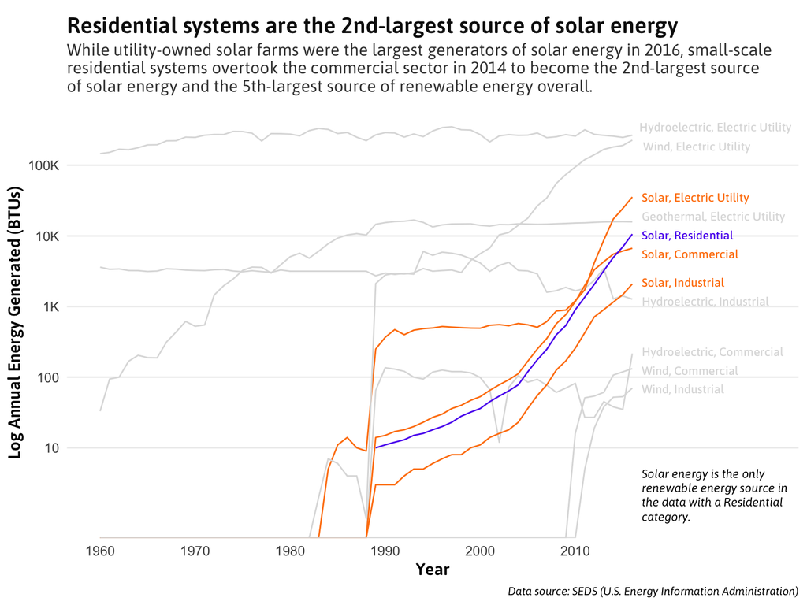

```r
gen %>%
  group_by(Year, source, energy_type) %>%
  summarize(total_btu = sum(Data)) %>%
  mutate(full_source = paste0(energy_type, ", ", source)) %>%
  mutate(highlight_col = ifelse(source == "Residential", "2",
                              ifelse(energy_type == "Solar", "1", "0"))) %>%
  ##### PLOT BEGINS
  ggplot(aes(x = Year, y = total_btu, group = full_source, color = highlight_col)) +
  geom_line(show.legend = FALSE,
            na.rm = TRUE) +
  scale_color_manual(values = c("#DDDDDD", "#FF810F", "#5D2BF0")) +
  labs(title = "Residential systems are the 2nd-largest source of solar energy",
       subtitle = "While utility-owned solar farms were the largest generators of solar energy in 2016, small-scale \nresidential systems overtook the commercial sector in 2014 to become the 2nd-largest source \nof solar energy and the 5th-largest source of renewable energy overall.",
       x = "Year",
       y = "Log Annual Energy Generated (BTUs)",
       caption = "Data source: SEDS (U.S. Energy Information Administration)") +
  geom_text_repel(data = . %>% filter(Year == 2016),
                  aes(x = Year, y = total_btu, label = full_source),
                  size = 3,
                  hjust = 0,
                  nudge_x = 1,
                  family = "Asap Medium",
                  show.legend = FALSE,
                  na.rm = TRUE) +
  scale_y_log10(breaks = c(10, 100, 1000, 10000, 100000),
                labels = c("10", "100", "1K", "10K", "100K")) +
  scale_x_continuous(limits = c(1960, 2030),
                     breaks = seq(1960, 2010, 10)) +
  annotate(geom = "text", x = 2017, y = 5,
           label = "Solar energy is the only \nrenewable energy source in \nthe data with a Residential \ncategory.",
           size = 3,
           lineheight = 1,
           color = "#000000",
           hjust = 0, vjust = 1,
           family = "Asap",
           fontface = "italic") +
  theme_custom() +
  theme(panel.grid.major.x = element_blank())
```

```r
ggsave(here('output', 'gen-by-source.png'), width = 8, height = 6)
```

A logical next question is: who’s actually capturing all this solar energy?

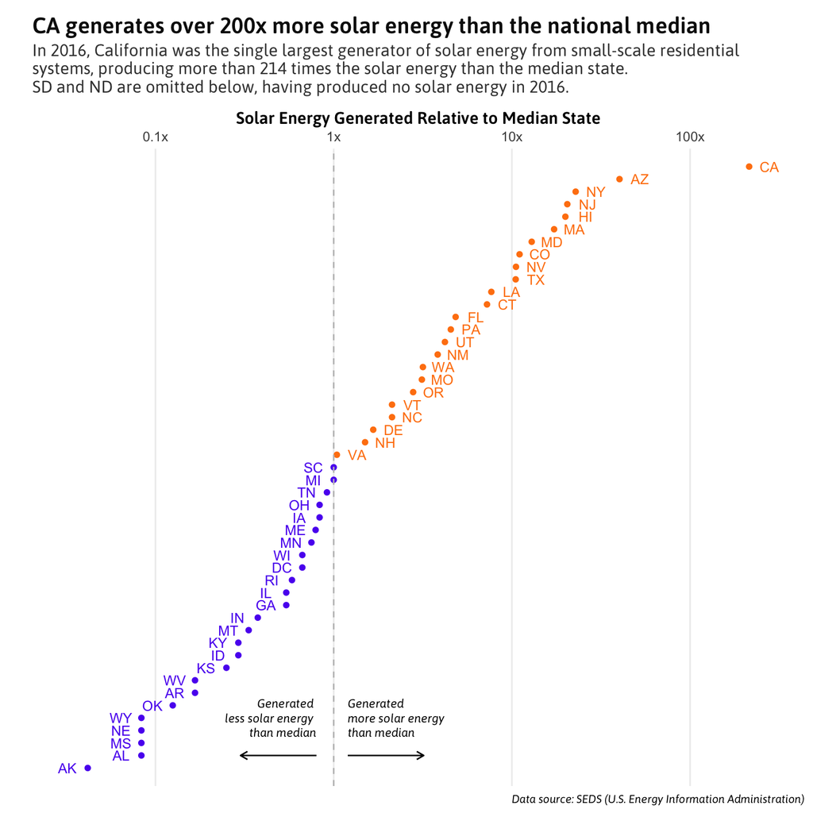

```r
gen %>%
  filter(Year == max(Year)) %>%
  filter(source == "Residential") %>%
  group_by(StateCode) %>%
  summarize(total_btu = sum(Data)) %>%
  mutate(dev_fr_median = total_btu / median(total_btu, na.rm = TRUE)) %>%
  filter(dev_fr_median != 0) %>% # SD and ND mess with log scale; omit
  mutate(highlight = ifelse(dev_fr_median > 1, TRUE, FALSE)) %>%
  ##### PLOT BEGINS
  ggplot(aes(x = reorder(StateCode, dev_fr_median), y = dev_fr_median, color = highlight)) +
  geom_point(stat = 'identity',
             show.legend = FALSE,
             na.rm = TRUE) +
  geom_text(aes(label = StateCode,
                 y = ifelse(dev_fr_median > 1, dev_fr_median * 1.3, dev_fr_median / 1.3)),
            show.legend = FALSE,
            size = 3.5) +
  geom_hline(yintercept = 1,
             color = "#BFBFBF",
             linetype = "dashed") +
  scale_y_log10(position = "right",
                breaks = c(0.01, 0.1, 1, 10, 100),
                labels = c("0.01x", "0.1x", "1x", "10x", "100x")) +
  scale_x_discrete(expand = c(0.03, 0)) +
  scale_color_manual(values = c("#5D2BF0", "#FF810F")) +
  labs(title = "CA generates over 200x more solar energy than the national median",
       subtitle = "In 2016, California was the single largest generator of solar energy from small-scale residential \nsystems, producing more than 214 times the solar energy than the median state. \nSD and ND are omitted below, having produced no solar energy in 2016.",
       x = "",
       y = "Solar Energy Generated Relative to Median State",
       caption = "Data source: SEDS (U.S. Energy Information Administration)") +
  annotate("segment",
           x = "AL", xend = "AL",
           y = 1.2, yend = 3.2,
           arrow = arrow(length = unit(0.2, "cm")),
           color = "#000000") +
  annotate("segment",
           x = "AL", xend = "AL",
           y = 0.8, yend = 0.3,
           arrow = arrow(length = unit(0.2, "cm")),
           color = "#000000") +
  annotate("text",
           x = "WY", y = 1.2,
           label = "Generated \nmore solar energy \nthan median",
           family = "Asap",
           fontface = "italic",
           color = "#000000",
           size = 3,
           lineheight = 1,
           hjust = 0) +
  annotate("text",
           x = "WY", y = 0.8,
           label = "Generated \nless solar energy \nthan median",
           family = "Asap",
           fontface = "italic",
           color = "#000000",
           size = 3,
           lineheight = 1,
           hjust = 1) +
  theme_custom() +
  theme(panel.grid.major.y = element_blank(),
        axis.text.y = element_blank()) +
  coord_flip()
```

```r
# ggsave(here('output', 'gen-by-state-mul.png'), width = 8, height = 8)
```

Unsurprisingly, California was the single largest **residential** generator of solar energy in 2016 - in fact, California and Arizona combined generated more than half of the national total. What is a bit more of a surprise is how high on the list the Northeast states like New York (#3), New Jersey (#4), and Massachussetts (#6) lie, particularly in comparison to known sunny states like Nevada (#9), Texas (#10) and Florida (#13).

That brings me to my next question: does the amount of sunlight each state receives correlate with the solar energy it generates?

# Do sunny states generate more solar energy?

For this, we’ll use solar irradiance data from the Department of Energy’s [National Renewable Energy Laboratory](https://www.nrel.gov/gis/data-solar.html). Specifically, we’re looking at Global Horizontal Irradiance (GHI), which is the amount of solar radiation a surface receives if placed horizonal to the ground, measured in kilowatt-hours per square meter per day ($kWh/m^2/day$). Since we’re dealing with residential installations here, roofs might be sloped in a particular direction, but we’ll assume that they more or less average out to horizontal position in the full dataset.

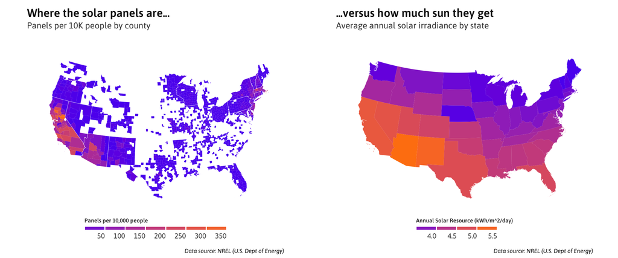

```r
# Specify map bounds
bounds <- data_frame(LONG = c(-122, -64),
                     LAT = c(24, 49)) %>%
  st_as_sf(coords = c("LONG", "LAT"),
           crs = 4326) %>%
  st_transform(crs = 2163) %>%
  st_coordinates()
# Plot Solar Panel Map
map1 <- county_map %>%
  st_transform(2163) %>%
  mutate(COUNTYFP = as.character(COUNTYFP)) %>%
  left_join(panels %>%
              filter(install_type == "residential") %>%
              select(zipcode) %>%
              left_join(zip_codes, by = c("zipcode" = "zip")) %>%
              group_by(fips) %>%
              count(),
            by = c("GEOID" = "fips")) %>%
  left_join(counties %>%
              mutate(GEOID = paste0(state_fips, county_fips)) %>%
              select(GEOID, population),
            by = c("GEOID" = "GEOID")) %>%
  mutate(panels_per_10k = ((n * 10000) / population)) %>%
  ##### PLOT BEGINS
  ggplot() +
  geom_sf(aes(fill = panels_per_10k),
          color = "transparent") +
  geom_sf(data = us_states,
          fill = "transparent",
          color = "#FFFFFF",
          size= 0.1) +
  coord_sf(xlim = bounds[, 1],
           ylim = bounds[, 2]) +
  scale_fill_gradient(low = "#5D2BF0", high = "#FF810F",
                      na.value = "#FFFFFF",
                      name = "Panels per 10,000 people",
                      breaks = seq(0, 400, 50),
                      guide = guide_legend(
                        direction = "horizontal",
                        keyheight = unit(2, units = "mm"),
                        keywidth = unit(10, units = "mm"),
                        title.position = "top",
                        title.hjust = 0,
                        label.hjust = 1,
                        nrow = 1,
                        byrow = TRUE,
                        label.position = "bottom"
                      )) +
  labs(title = "Where the solar panels are...",
       subtitle = "Panels per 10K people by county",
       caption = "Data source: NREL (U.S. Dept of Energy)") +
  theme_custom() +
  theme(panel.grid.major = element_line(color = "#FFFFFF"),
        axis.text = element_blank(),
        axis.title = element_blank(),
        legend.position = "bottom",
        legend.title = element_text(size = 8))
# Plot Solar Resource Map
map2 <- us_states %>%
  st_transform(2163) %>%
  left_join(ghi %>%
              filter(period == "Ann") %>%
              select(State, avg),
            by = c("name" = "State")) %>%
  ##### PLOT BEGINS
  ggplot() +
  geom_sf(aes(fill = avg),
          color = "transparent") +
  coord_sf(xlim = bounds[, 1],
           ylim = bounds[, 2]) +
  scale_fill_gradient(low = "#5D2BF0", high = "#FF810F",
                      na.value = "#FFFFFF",
                      name = "Annual Solar Resource (kWh/m^2/day)",
                      breaks = seq(3, 6, 0.5),
                      guide = guide_legend(
                        direction = "horizontal",
                        keyheight = unit(2, units = "mm"),
                        keywidth = unit(10, units = "mm"),
                        title.position = "top",
                        title.hjust = 0,
                        label.hjust = 1,
                        nrow = 1,
                        byrow = TRUE,
                        label.position = "bottom"
                      )) +
  labs(title = "...versus how much sun they get",
       subtitle = "Average annual solar irradiance by state",
       caption = "Data source: NREL (U.S. Dept of Energy)") +
  theme_custom() +
  theme(legend.position = "bottom",
        legend.title = element_text(size = 8),
        panel.grid.major = element_line(color = "#FFFFFF"),
        axis.text = element_blank(),
        axis.title = element_blank())
# grid.arrange(map1, map2, ncol = 2)
pair_map <- grid.arrange(map1, map2, ncol = 2)
```

```r
ggsave(filename = here::here('output', 'map-pair.png'),
      plot = pair_map,
      width = 12, height = 5)
```

As we’ve seen before, however, map pairs aren’t the best at showing correlation. So let’s try another way of looking at how solar energy generation correlates with solar irradiance.

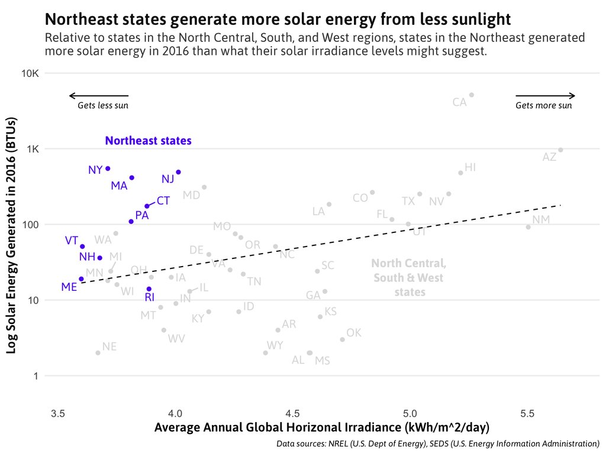

```r
gen %>%
  filter(Year == 2016) %>%
  filter(source == "Residential") %>%
  group_by(StateCode) %>%
  summarize(total_btu = sum(Data)) %>%
  left_join(ghi %>%
               mutate(StateCode = state.abb[match(State, state.name)]) %>%
               filter(period == "Ann", !is.na(avg)) %>%
               select(StateCode, avg),
             by = c("StateCode" = "StateCode")) %>%
  filter(total_btu != 0) %>%  # SD and ND mess with log scale
  mutate(region = state.region[match(StateCode, state.abb)]) %>%
  mutate(highlight = ifelse(region == "Northeast", "Northeast", "North Central, \nSouth & West")) %>%
  ##### PLOT BEGINS
  ggplot(aes(x = avg, y = total_btu, label = StateCode, color = highlight)) +
  geom_point(show.legend = FALSE,
             na.rm = TRUE) +
  geom_text_repel(show.legend = FALSE,
                  na.rm = TRUE,
                  family = "Asap") +
  geom_smooth(aes(x = avg, y = total_btu),
              method = "lm",
              color = "black",
              size = 0.5,
              linetype = "dashed",
              se = FALSE,
              inherit.aes = FALSE,
              na.rm = TRUE) +
  scale_y_log10(expand = c(0.1, 0),
                breaks = c(1, 10, 100, 1000, 10000),
                labels = c("1", "10", "100", "1K", "10K")) +
  scale_color_manual(values = c("#DDDDDD", "#5D2BF0"),
                     name = "Region") +
  labs(title = "Northeast states generate more solar energy from less sunlight",
       subtitle = "Relative to states in the North Central, South, and West regions, states in the Northeast generated \nmore solar energy in 2016 than what their solar irradiance levels might suggest.",
       x = "Average Annual Global Horizonal Irradiance (kWh/m^2/day)",
       y = "Log Solar Energy Generated in 2016 (BTUs)",
       caption = "Data sources: NREL (U.S. Dept of Energy), SEDS (U.S. Energy Information Administration)") +
  annotate("segment",
           x = 3.8, xend = 3.55, y = 5000, yend = 5000,
           arrow = arrow(length = unit(0.2, "cm")),
           color = "#000000") +
  annotate("segment",
           x = 5.45, xend = 5.7, y = 5000, yend = 5000,
           arrow = arrow(length = unit(0.2, "cm")),
           color = "#000000") +
  annotate("text",
           x = 3.8, y = 3800,
           label = "Gets less sun",
           color = "#000000",
           family = "Asap",
           fontface = "italic",
           size = 3,
           hjust = 1) +
  annotate("text",
           x = 5.45, y = 3800,
           label = "Gets more sun",
           color = "#000000",
           family = "Asap",
           fontface = "italic",
           size = 3,
           hjust = 0) +
  annotate("text",
           x = 3.7, y = 1300,
           label = "Northeast states",
           color = "#5D2BF0",
           family = "Asap Bold",
           size = 4,
           hjust = 0) +
  annotate("text",
           x = 5.0, y = 20,
           label = "North Central, \nSouth & West \nstates",
           lineheight = 1,
           color = "#DDDDDD",
           family = "Asap Bold",
           size = 4,
           hjust = 0.5) +
  theme_custom() +
  theme(panel.grid.minor = element_blank(),
        panel.grid.major.x = element_blank(),
        legend.position = c(0.87, 0.15),
        legend.background = element_rect(color = "#BFBFBF"))
```

```r
ggsave(here('output', 'ghi-vs-gen.png'), width = 8, height = 6)
```

While there are plenty of factors that impact the efficiency with which you generate solar energy - tilt, weather, temperature, age of technology, etc. - my immediate guess is that the most straightforward way to ramp up your output is to have more solar panels.